# COAX STORY

Maryam Khezrzadeh

2018-11-04

### [Coax](https://louderthanten.com/coax) is a digital magazine for people who love projects. It’s designed and published by [Louder Than Ten](https://louderthanten.com/). We were *curious about the content of coax*, so we started an **exploratory data analysis** …

[figure not shown]

## About The Data

Our data is three parts:

#### Article Metadata

Basic inforamtion about each article, such as the author and date of publication were harvested from [coax archive](https://louderthanten.com/coax/archive) online.

#### Article Contents

The content of coax magazine was automatically harvested from the web by `hypertools` and then cleaned up to make sure it only contains the text of the articles.

#### Public Engagement Metrics

These are metrics on how successfull the articles have been on engaing the public, e.g. number of visists / reads / shares.

## 5 Years of Coax

The COAX DASHBORAD provides an overview of the content.

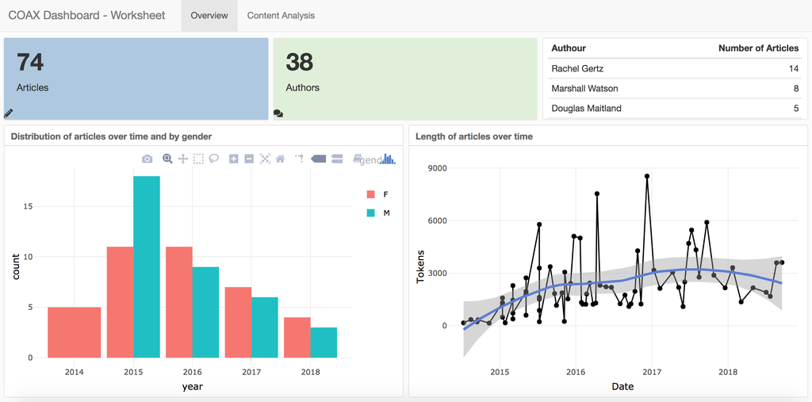

## What have we written about?

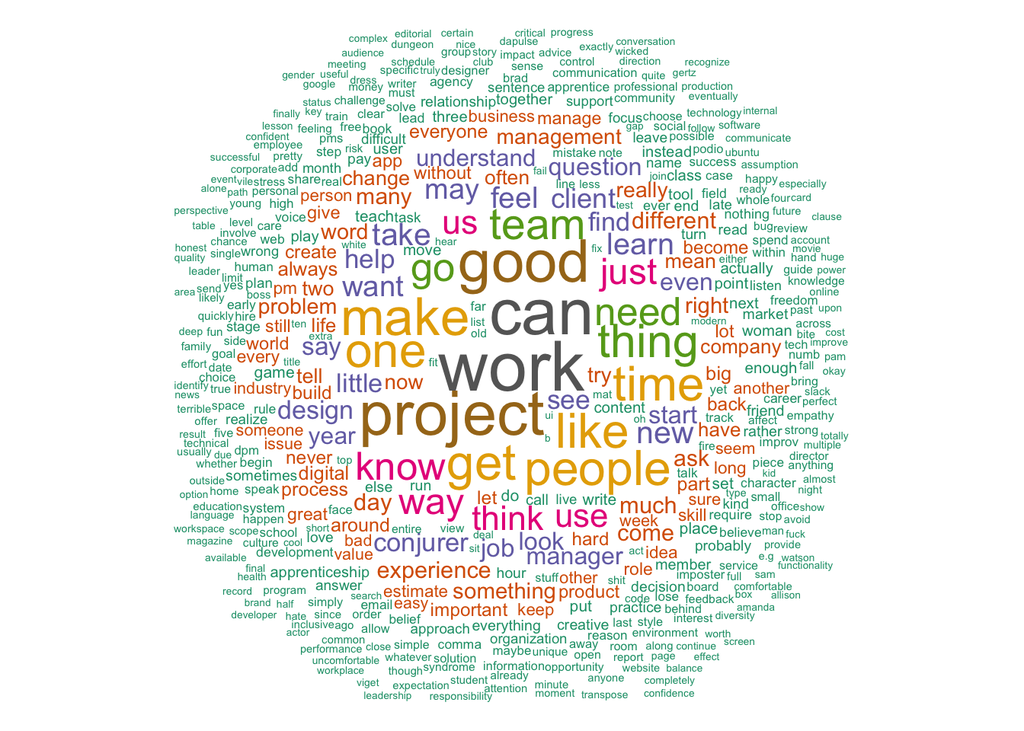

The wordcloud above gives *some sense* of the content in coax. But it doesn’t inform much. These words are not particularly surprising. We expect from a magazine on project panagement to talk of projects, work and people! Could we maybe generate another wordcloud that gives a more interesting image of the content?

### Looking at two words instead of single words

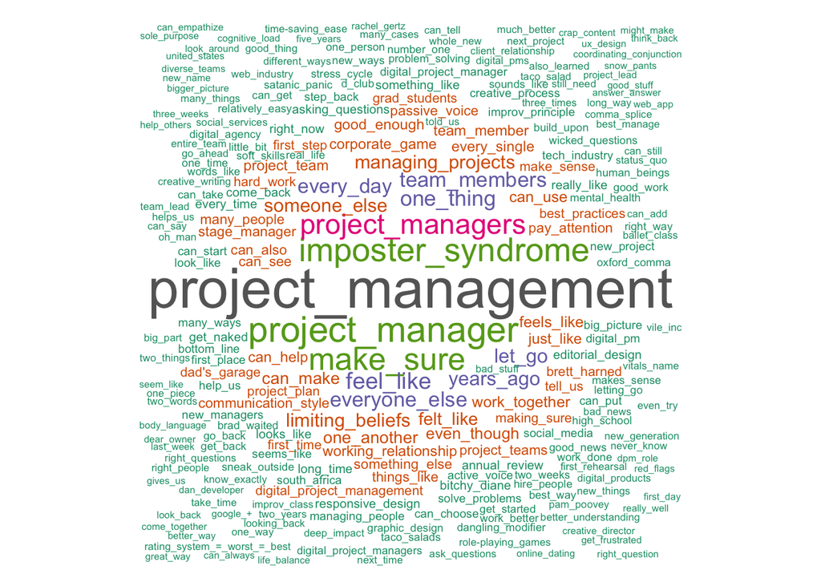

This wordcloud is slightly more interesting as it provides more context. We see interesting phrases like “imposter syndrome” and “asking_questions” and “best practices” turn up. These more solidly hint at the type of topics the articles are discussing.

It’s also important to notice the noise in this pictures. We see lots of phrases that are just of figure of speach and not particularly informative about the content of coax. For example “make sure” or “every day”, “feel like”, etc. How can we reduce these noise and zoom in and focus a bit more?

### Pealing layers of complexity